# Time Series Homework: Chapter 4 Lesson 3

## Data

```r
ind_prod <- rio::import("https://byuistats.github.io/timeseries/data/ind_prod_us.csv")
```

## Questions

### Question 1 - AR(1) with non-zero mean (10 points)

An AR(1) process with a non-zero mean $\mu$ can be expressed by either:

$$x_t-\mu=\alpha_1(x_{t-1}-\mu)+w_t \hspace{5mm}\mbox{or}\hspace{5mm}x_t=\alpha_0+\alpha_1x_{t-1}+w_t$$

#### a) Define a similar relationship for an AR(2) process with mean $\mu$

**Answer**

$$x_t - \mu = \alpha_1(x_{t-1} - \mu) + \alpha_2(x_{t-2} - \mu) + w_t$$

### Question 2 - Stationarity (25 points)

#### a) Show that the series {$x_t$} given by $x_t=\frac{3}{2}x_{t-1}-\frac{1}{2}x_{t-2}+w_t$ is non-stationary. Please use the characteristic equation method.

**Answer**

$$1 - \frac{3}{2}B + \frac{1}{2}B^2 = 0$$

We then calculate the value of $B$ using the polyroot function.

```r
polyroot(c(1, -3/2, .5)) |> abs() |> round(3)
```

```
[1] 1 2
```

This shows that $B$ is equal to 1 and 2. Because the absolute value of at least one of the coefficients is less than or equal to 1, it is non stationary.

#### b) Please simulate the series {$x_t$} using 1000 realizations and calculate the first difference {$y_t$}, where $y_t=\nabla x_t$.

**Answer**

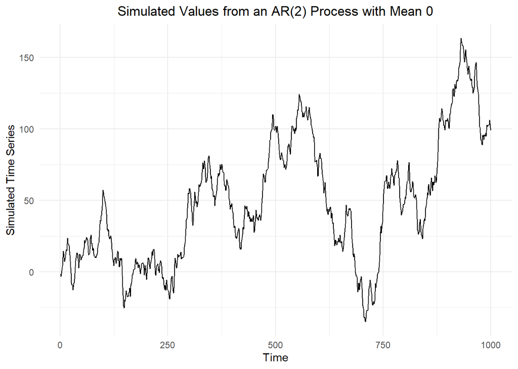

```r
set.seed(123)
n_rep <- 1000
alpha0 <- 0
alpha1 <- 1.5
alpha2 <- -0.5
sigma_sqr <- 9

dat_ts <- tibble(w = rnorm(n = n_rep, sd = sqrt(sigma_sqr))) |>
    mutate(
      index = 1:n(),
      x = 0
    ) |>
  mutate(y = w - lag(w)) |>
    tsibble::as_tsibble(index = index)

# Simulate x values
dat_ts$x[1] <- alpha0 + dat_ts$w[1]
dat_ts$x[2] <- alpha0 + alpha1 * ( dat_ts$x[1] - alpha0 ) + dat_ts$w[2]
for (i in 3:nrow(dat_ts)) {
  dat_ts$x[i] <- alpha0 +
    alpha1 * ( dat_ts$x[i-1] - alpha0 ) +
    alpha2 * ( dat_ts$x[i-2] - alpha0 ) +
    dat_ts$w[i]
}

dat_ts |>
  autoplot(.vars = x) +
    labs(
      x = "Time",
      y = "Simulated Time Series",
      title = paste("Simulated Values from an AR(2) Process with Mean", alpha0)
    ) +
    theme_minimal() +
    theme(
      plot.title = element_text(hjust = 0.5)
    )
```

[figure not shown]

```r
dat_ts |>
  autoplot(.vars = y) +
    labs(
      x = "Time",
      y = "Simulated Time Series",
      title = paste("Simulated Values from the first difference of an AR(2) Process with Mean", alpha0)
    ) +
    theme_minimal() +
    theme(
      plot.title = element_text(hjust = 0.5)
    )
```

#### c) Prove that $y_t$ is stationary, use the characteristic equation method.

**Answer**

$$1 - (\frac{3}{2} - 1)B + \frac{1}{2}B^2 = 0$$

$$1 - \frac{1}{2}B + \frac{1}{2}B^2 = 0$$

We then calculate the value of $B$ using the polyroot function.

```r
polyroot(c(1, -1/2, .5)) |> abs() |> round(3)
```

```
[1] 1.414 1.414
```

This shows that $B$ is equal to 1.414. Because the absolute value of all of the coefficients is greater than 1, it is stationary.

#### a) Please use the Holt-Winters method to decompose the US Industrial Production Index. Please justify your choice of parameters. Use the context and your understanding of the series as part of your answers.

**Answer**

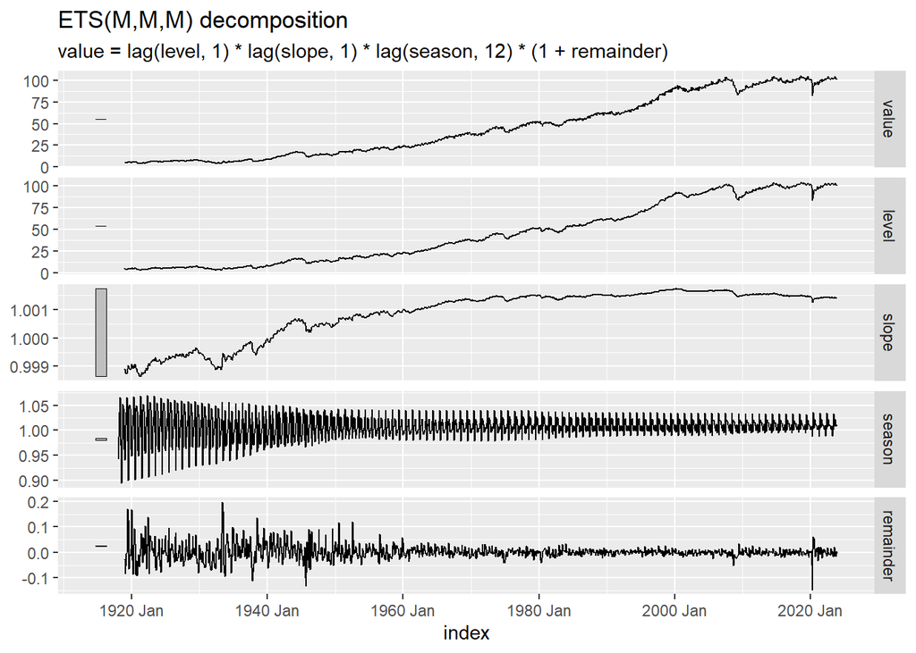

```r
ind_prod$date <- as.Date(ind_prod$date)

# Create a time series object
ind_prod_tsibble <- ts(ind_prod$ind_prod_indx, start = c(1919, 1), frequency = 12)

ind_prod_tsibble <- ind_prod_tsibble %>% as_tsibble(index=date)


ipi_hw <- ind_prod_tsibble |>
  model(Additive = ETS(value ~
        trend("M", alpha=0.95, beta=0.001) +
        error("M") +
        season("M", gamma=0.05),
        opt_crit = "amse", nmse = 1))

autoplot(components(ipi_hw))
```

```r
report(ipi_hw)
```

```
Series: value
Model: ETS(M,M,M)
  Smoothing parameters:
    alpha = 0.95
    beta  = 0.001
    gamma = 0.05

  Initial states:
     l[0]      b[0]      s[0]    s[-1]    s[-2]    s[-3]     s[-4]     s[-5]
 5.226678 0.9989126 0.9620496 1.044403 1.051327 1.051801 0.9819087 0.8943017
     s[-6]    s[-7]    s[-8]    s[-9]    s[-10]    s[-11]
 0.9700078 1.066222 1.035825 1.013137 0.9863021 0.9427153

  sigma^2:  9e-04

     AIC     AICc      BIC
8688.486 8688.824 8760.431
```

The values chosen were $\alpha$ at a value of 0.95, $\beta$ at a value of 0.001, $\gamma$ at a value of 0.05. A multiplicative model was chosen The high value for $\alpha$ was selected as there could be large fluctuations and economic shocks that could affect the series. By setting $\alpha$ at a higher value we place greater emphasis on more recent values to affect the level. $\beta$ and $\gamma$ are set to lower values, as the long term trend is consistent as is the seasonality. Any changes that may occur would be gradual and so the smaller values are set to reflect that.

#### b) Plot the remainder (random) component of the decomposed series.

**Answer**

```r
random <- ipi_hw |>
  residuals() |>
  as_tibble()
```

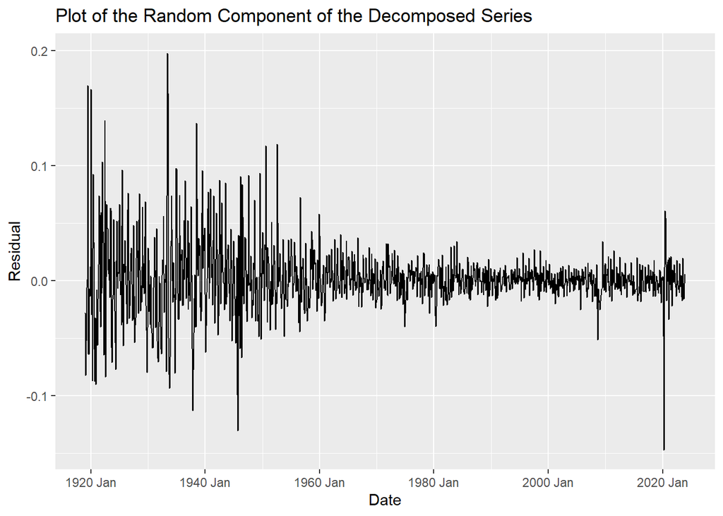

```r
ggplot(random, aes(x = index, y = .resid))+
  geom_line() +
  labs(x= "Date",
       y = "Residual",
       title = "Plot of the Random Component of the Decomposed Series")
```

#### c) Plot a partial correlogram of the random component of the the US Industrial Production Index. What kind of autoregressive process would you pick to model the random component?

**Answer**

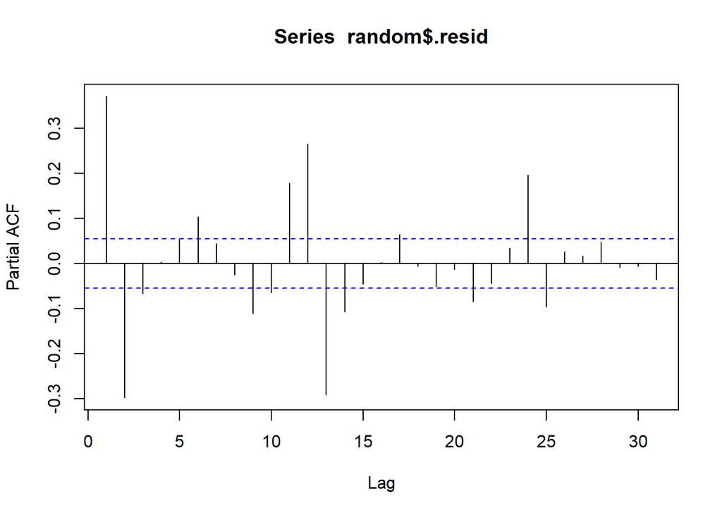

```r
pacf(random$.resid)
```

### Rubric

[output not shown]